# Terns wing-normalized mass trends over time

Issue #6 - follow-up to issue #5 task 3, per Yosef’s suggestion

2026-09-20

# 1 Background

Issue #5 task 3 found that confirmed breeders show a significantly steeper mass decline over time than juveniles or non-breeders, in both species (see `03_mass_trends.Rmd`). Yosef suggested normalizing mass to wing (chord) length before drawing conclusions from a mass trend, on the theory that raw mass could partly reflect body-size differences in the sample rather than body condition per se.

This is not a settled methods question. A simple mass/wing ratio assumes a proportional, through-origin relationship between the two, which body mass rarely follows exactly. The better-supported alternative in the literature is the **scaled mass index (SMI)** (Peig & Green 2009): fit a standardized major axis (SMA) regression of `log(Weight)` on `log(Wing)`, then rescale each individual’s mass to what it would be at the group’s mean wing length, using the SMA slope as the scaling exponent. Both are computed here, side by side, rather than picking one upfront.

Same three groups as issue #5 task 3, per species: **Juvenile** (age 3, Jun-Aug), **Adult breeder** and **Adult non-breeder** (spring weight, task 2c any-year confirmed-breeder split).

# 2 Data loading

```r
raw_dir <- "../data_raw"
if (!dir.exists(raw_dir)) raw_dir <- "data_raw"
stopifnot(dir.exists(raw_dir))

proc_dir <- "../data_processed"
if (!dir.exists(proc_dir)) proc_dir <- "data_processed"

out_dir <- "../output"
if (!dir.exists(out_dir)) out_dir <- "output"

ringing_path <- file.path(raw_dir, "ringing_data_raw.xlsx")
stopifnot(file.exists(ringing_path))

col_names_47 <- c(
  "CR1","RingReplace","Rec","RingPrefix","RingNum","Species","Sex","Age","Wing","Weight",
  "Date","Time","Place","Lat","Lon","Ringer","Country","Remarks","Net","CR2","Subsp","Tail","Head",
  "Breeding","CP1","CP2","CP3","CP4","Colour","D","M","OrigDate","OrigCountry","OrigLat","OrigLon","OrigAge",
  "OldCR1","OldCR2","OldCR3","OldMetal1","OldMetal2","OilHead","OilWings","OilUpperP","OilUnderP","OilLegs","OilSum"
)
raw <- read_excel(ringing_path, sheet = "Data", skip = 2, col_names = col_names_47)

terns <- raw %>%
  filter(Species %in% c("STEALB", "STEHIR")) %>%
  mutate(
    year = year(Date),
    month = month(Date),
    ring_id = paste0(trimws(RingPrefix), RingNum),
    is_new = is.na(Rec) | trimws(Rec) == "",
    species_label = ifelse(Species == "STEHIR", "Common Tern", "Little Tern")
  )
```

# 3 Building the three comparison groups

Identical construction to `03_mass_trends.Rmd`, with the added requirement that `Wing` (not just `Weight`) is present - `Wing`/`Weight` are both capture-only fields, so this drops very few extra records (checked below).

```r
juvenile_records <- terns %>%
  filter(is_new, Age == 3, !is.na(Weight), month %in% 6:8) %>%
  mutate(group = "Juvenile")

juvenile_ages <- c(1, 3)
summer_ring_ids_anyyear <- terns %>%
  filter(month %in% 6:7) %>%
  distinct(ring_id) %>%
  pull(ring_id)

spring_adults_anyyear <- terns %>%
  filter(!(Age %in% juvenile_ages), !is.na(Weight), month %in% 3:5) %>%
  mutate(confirmed_breeder_anyyear = ring_id %in% summer_ring_ids_anyyear,
         group = ifelse(confirmed_breeder_anyyear, "Adult breeder", "Adult non-breeder"))

combined_records_raw <- bind_rows(
  juvenile_records,
  spring_adults_anyyear %>% select(-confirmed_breeder_anyyear)
) %>%
  mutate(group = factor(group, levels = c("Juvenile", "Adult non-breeder", "Adult breeder")))

n_before <- nrow(combined_records_raw)
combined_records <- combined_records_raw %>% filter(!is.na(Wing))
n_after <- nrow(combined_records)

cat("Records with Weight:", n_before, "- also with Wing:", n_after,
    sprintf("(%.1f%% retained)\n", 100 * n_after / n_before))
```

```
## Records with Weight: 3914 - also with Wing: 3905 (99.8% retained)
```

```r
kable(
  combined_records %>% group_by(species_label, group) %>%
    summarise(n = n(), n_years = n_distinct(year),
              min_year = min(year), max_year = max(year), .groups = "drop"),
  caption = "Weight+Wing coverage by species and group"
)
```

Weight+Wing coverage by species and group

| species_label | group | n | n_years | min_year | max_year |
| --- | --- | --- | --- | --- | --- |
| Common Tern | Juvenile | 1230 | 17 | 2010 | 2026 |
| Common Tern | Adult non-breeder | 1593 | 16 | 2011 | 2026 |
| Common Tern | Adult breeder | 485 | 16 | 2011 | 2026 |
| Little Tern | Juvenile | 191 | 12 | 2010 | 2025 |
| Little Tern | Adult non-breeder | 224 | 16 | 2011 | 2026 |
| Little Tern | Adult breeder | 182 | 14 | 2011 | 2026 |

# 4 Does wing length itself trend over time?

Before normalizing, check whether `Wing` shows its own temporal trend within each group - if it doesn’t, wing-normalized mass should track raw mass closely, and this adjustment won’t tell us much new for that group.

```r
wing_trend <- combined_records %>%
  group_by(species_label, group) %>%
  filter(n() >= 10, n_distinct(year) >= 3) %>%
  group_modify(~ {
    m <- lm(Wing ~ year, data = .x)
    s <- summary(m)
    tibble(
      n = nrow(.x),
      slope_mm_per_year = round(coef(m)["year"], 4),
      p_value = signif(s$coefficients["year", "Pr(>|t|)"], 3)
    )
  }) %>%
  ungroup()

kable(wing_trend, caption = "Wing ~ year regression, by species and group")
```

Wing ~ year regression, by species and group

| species_label | group | n | slope_mm_per_year | p_value |
| --- | --- | --- | --- | --- |
| Common Tern | Juvenile | 1230 | 0.2281 | 0.0612 |
| Common Tern | Adult non-breeder | 1593 | 0.1245 | 0.0015 |
| Common Tern | Adult breeder | 485 | 0.0304 | 0.6950 |
| Little Tern | Juvenile | 191 | 0.6291 | 0.0509 |
| Little Tern | Adult non-breeder | 224 | 0.1641 | 0.0434 |
| Little Tern | Adult breeder | 182 | 0.0630 | 0.5050 |

# 5 Two normalization methods

## 5.1 Simple ratio

```r
combined_records <- combined_records %>%
  mutate(mass_ratio = Weight / Wing)
```

## 5.2 Scaled mass index (SMI, Peig & Green 2009)

SMA slope `b` fit **per species x group** (juveniles, breeders and non-breeders may have genuinely different mass-wing scaling relationships, so pooling would misrepresent all three) on `log(Weight) ~ log(Wing)`. Each individual’s mass is then rescaled to what it would weigh at that group’s mean wing length:

`SMI_i = Weight_i * (Wing_mean / Wing_i) ^ b`

where `b` is the SMA slope, `sd(log Weight) / sd(log Wing)` (equivalent to the OLS slope divided by the correlation coefficient).

```r
compute_smi <- function(df) {
  lx <- log(df$Wing)
  ly <- log(df$Weight)
  b <- sd(ly) / sd(lx)  # SMA slope
  wing_mean <- mean(df$Wing)
  df$smi <- df$Weight * (wing_mean / df$Wing) ^ b
  df$smi_b <- b
  df
}

combined_records <- combined_records %>%
  group_by(species_label, group) %>%
  group_modify(~ compute_smi(.x)) %>%
  ungroup()

kable(
  combined_records %>% distinct(species_label, group, smi_b) %>% arrange(species_label, group),
  digits = 3, caption = "SMA slope (b) used for SMI, by species and group"
)
```

SMA slope (b) used for SMI, by species and group

| species_label | group | smi_b |
| --- | --- | --- |
| Common Tern | Juvenile | 1.287 |
| Common Tern | Adult non-breeder | 3.608 |
| Common Tern | Adult breeder | 3.384 |
| Little Tern | Juvenile | 0.895 |
| Little Tern | Adult non-breeder | 3.305 |
| Little Tern | Adult breeder | 3.459 |

# 6 Trend statistics, all three metrics side by side

```r
format_pval <- function(p) {
  ifelse(p < 0.001, formatC(p, format = "e", digits = 2), formatC(p, format = "f", digits = 3))
}

fit_trend <- function(df, response) {
  df %>%
    group_by(species_label, group) %>%
    filter(n() >= 3) %>%
    group_modify(~ {
      m <- lm(reformulate("year", response = response), data = .x)
      s <- summary(m)
      tibble(
        n = nrow(.x),
        n_years = n_distinct(.x$year),
        slope_per_year = round(coef(m)["year"], 4),
        se = round(s$coefficients["year", "Std. Error"], 4),
        p_value = signif(s$coefficients["year", "Pr(>|t|)"], 3),
        r_squared = round(s$r.squared, 3)
      )
    }) %>%
    ungroup() %>%
    mutate(metric = response)
}

trend_stats <- bind_rows(
  fit_trend(combined_records, "Weight"),
  fit_trend(combined_records, "mass_ratio"),
  fit_trend(combined_records, "smi")
) %>%
  mutate(metric = recode(metric, Weight = "Raw mass (g)",
                          mass_ratio = "Mass/Wing ratio",
                          smi = "SMI (g, rescaled)"),
         metric = factor(metric, levels = c("Raw mass (g)", "Mass/Wing ratio", "SMI (g, rescaled)"))) %>%
  arrange(species_label, group, metric)

trend_stats_display <- trend_stats %>%
  mutate(significant = p_value < 0.05, p_value_fmt = format_pval(p_value)) %>%
  mutate(p_value_fmt = ifelse(significant, paste0("<strong>", p_value_fmt, "</strong>"), p_value_fmt)) %>%
  select(species_label, group, metric, n, n_years, slope_per_year, se, p_value = p_value_fmt, r_squared)

kable(trend_stats_display, escape = FALSE,
      caption = "value ~ year regression, by species/group/metric (significant rows, p&lt;0.05, in bold)")
```

value ~ year regression, by species/group/metric (significant rows, p<0.05, in bold)

| species_label | group | metric | n | n_years | slope_per_year | se | p_value | r_squared |
| --- | --- | --- | --- | --- | --- | --- | --- | --- |
| Common Tern | Juvenile | Raw mass (g) | 1230 | 17 | -0.1055 | 0.0749 | 0.159 | 0.002 |
| Common Tern | Juvenile | Mass/Wing ratio | 1230 | 17 | -0.0010 | 0.0003 | **6.43e-04** | 0.009 |
| Common Tern | Juvenile | SMI (g, rescaled) | 1230 | 17 | -0.2855 | 0.0793 | **3.32e-04** | 0.010 |
| Common Tern | Adult non-breeder | Raw mass (g) | 1593 | 16 | -0.1734 | 0.0643 | **0.007** | 0.005 |
| Common Tern | Adult non-breeder | Mass/Wing ratio | 1593 | 16 | -0.0008 | 0.0002 | **2.49e-04** | 0.008 |
| Common Tern | Adult non-breeder | SMI (g, rescaled) | 1593 | 16 | -0.3864 | 0.0802 | **1.58e-06** | 0.014 |
| Common Tern | Adult breeder | Raw mass (g) | 485 | 16 | -0.5430 | 0.1139 | **2.50e-06** | 0.045 |
| Common Tern | Adult breeder | Mass/Wing ratio | 485 | 16 | -0.0020 | 0.0004 | **5.26e-07** | 0.051 |
| Common Tern | Adult breeder | SMI (g, rescaled) | 485 | 16 | -0.5967 | 0.1388 | **2.06e-05** | 0.037 |
| Little Tern | Juvenile | Raw mass (g) | 191 | 12 | 0.0930 | 0.0805 | 0.250 | 0.007 |
| Little Tern | Juvenile | Mass/Wing ratio | 191 | 12 | -0.0006 | 0.0007 | 0.397 | 0.004 |
| Little Tern | Juvenile | SMI (g, rescaled) | 191 | 12 | -0.0732 | 0.1033 | 0.479 | 0.003 |
| Little Tern | Adult non-breeder | Raw mass (g) | 224 | 16 | -0.1099 | 0.0726 | 0.132 | 0.010 |
| Little Tern | Adult non-breeder | Mass/Wing ratio | 224 | 16 | -0.0009 | 0.0004 | **0.022** | 0.023 |
| Little Tern | Adult non-breeder | SMI (g, rescaled) | 224 | 16 | -0.2595 | 0.0797 | **0.001** | 0.046 |
| Little Tern | Adult breeder | Raw mass (g) | 182 | 14 | -0.2330 | 0.0889 | **0.010** | 0.037 |
| Little Tern | Adult breeder | Mass/Wing ratio | 182 | 14 | -0.0014 | 0.0005 | **0.004** | 0.045 |
| Little Tern | Adult breeder | SMI (g, rescaled) | 182 | 14 | -0.2946 | 0.1066 | **0.006** | 0.041 |

# 7 Visual comparison

Trend lines are drawn only where that species/group/metric’s year slope is significant (p<0.05, per the `trend_stats` table above) - a flat/absent line means no detectable trend, rather than implying a weak trend still worth drawing.

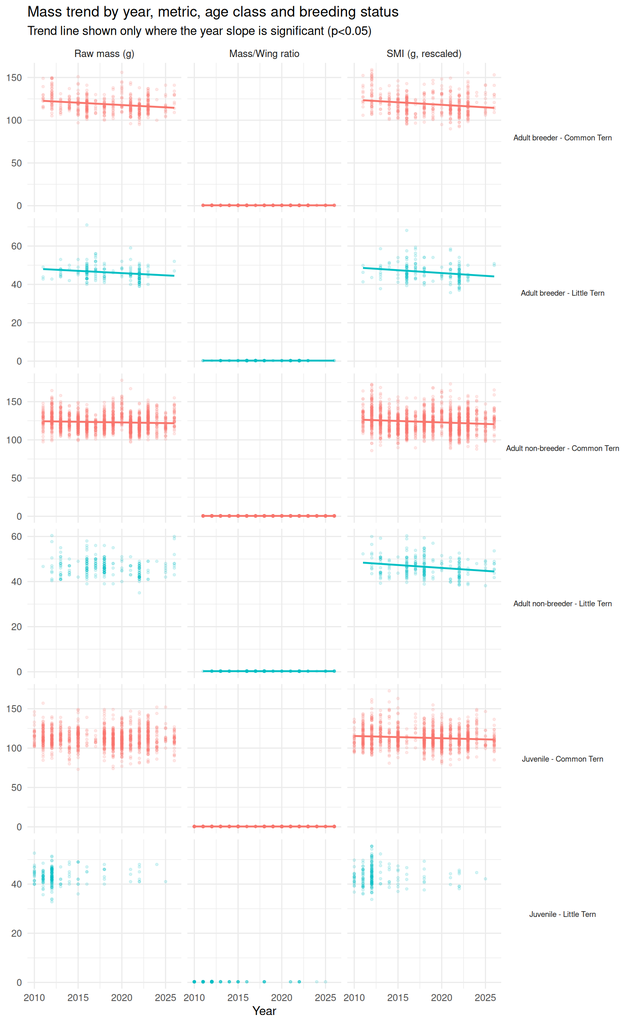

```r
long_records <- combined_records %>%
  select(species_label, group, year, Weight, mass_ratio, smi) %>%
  pivot_longer(cols = c(Weight, mass_ratio, smi), names_to = "metric", values_to = "value") %>%
  mutate(metric = recode(metric, Weight = "Raw mass (g)",
                          mass_ratio = "Mass/Wing ratio",
                          smi = "SMI (g, rescaled)"),
         metric = factor(metric, levels = c("Raw mass (g)", "Mass/Wing ratio", "SMI (g, rescaled)")),
         panel_label = paste(group, species_label, sep = " - "))

sig_combos <- trend_stats %>%
  filter(p_value < 0.05) %>%
  distinct(species_label, group, metric)

long_records_sig <- long_records %>% semi_join(sig_combos, by = c("species_label", "group", "metric"))

ggplot(long_records, aes(year, value, color = species_label)) +
  geom_point(alpha = 0.15, size = 0.8) +
  geom_smooth(data = long_records_sig, method = "lm", se = FALSE, linewidth = 0.8) +
  facet_grid(panel_label ~ metric, scales = "free_y") +
  guides(color = "none") +
  labs(title = "Mass trend by year, metric, age class and breeding status",
       subtitle = "Trend line shown only where the year slope is significant (p<0.05)",
       y = NULL, x = "Year") +
  theme_minimal() +
  theme(strip.text.y = element_text(angle = 0, size = 7), strip.text.x = element_text(size = 9))
```

# 8 Does the trend differ between groups? (interaction test, per metric)

```r
for (metric_col in c("Weight", "mass_ratio", "smi")) {
  metric_label <- recode(metric_col, Weight = "Raw mass", mass_ratio = "Mass/Wing ratio", smi = "SMI")
  cat("**", metric_label, "**\n\n", sep = "")
  for (sp in c("Common Tern", "Little Tern")) {
    d <- combined_records %>% filter(species_label == sp) %>% droplevels()
    m <- lm(reformulate(c("year", "group", "year:group"), response = metric_col), data = d)
    a <- anova(m)
    p_interaction <- signif(a["year:group", "Pr(>F)"], 3)
    cat("- ", sp, ": year x group interaction p = ", p_interaction, "\n", sep = "")
  }
  cat("\n")
}
```

**Raw mass**

- Common Tern: year x group interaction p = 0.00857
- Little Tern: year x group interaction p = 0.0335

**Mass/Wing ratio**

- Common Tern: year x group interaction p = 0.0635
- Little Tern: year x group interaction p = 0.547

**SMI**

- Common Tern: year x group interaction p = 0.173
- Little Tern: year x group interaction p = 0.274

## 8.1 Interpretation

Compare each metric’s breeder-vs-non-breeder-vs-juvenile pattern against the raw-mass result from issue #5 task 3 (Common Tern breeder slope -0.55 g/year, p=1.6e-06; Little Tern breeder slope -0.24 g/year, p=0.007, both significantly steeper than the other two groups). If the wing-normalized metrics show the same qualitative pattern (breeders declining faster, comparable significance), that’s reassurance the raw-mass finding isn’t an artifact of changing body size in the sample. If normalization substantially weakens or removes the breeder-specific decline, that suggests the raw-mass trend was at least partly a size effect rather than a condition effect - see the `Wing ~ year` check above for whether that’s plausible per group.

# 9 Save outputs

```r
write.csv(combined_records %>% select(-smi_b),
          file.path(proc_dir, "normalized_mass_records.csv"), row.names = FALSE)
write.csv(trend_stats, file.path(proc_dir, "normalized_mass_trends_stats.csv"), row.names = FALSE)
cat("Wrote data_processed/normalized_mass_records.csv and normalized_mass_trends_stats.csv\n")
```

```
## Wrote data_processed/normalized_mass_records.csv and normalized_mass_trends_stats.csv
```